# Project04

Hello, This is my Data Mining Project 4. Today, we will be doing analysis and applying clustering techniques using the Wholesale Customers Dataset, which contains annual spending data from clients of a wholesale distributor. This dataset is ideal for exploring customer segmentation, where clustering is commonly used in business analytics.

### The aim of this analysis

Today I will assume the role of a data analyst working for a wholesale distributor. My objective is to analyze the customer spending data and use clustering techniques to identify unique customer segments. Some of the questions we aim to answer include the following:

- Can we group customers into meaningful segments based on their purchasing behavior?
- What characteristics define each customer segment?
- How can the business use these insights to improve making decisions, marketing strategies, and customer service?

### About the data

The link to the dataset: [Wholesale Customers Dataset](https://www.kaggle.com/datasets/binovi/wholesale-customers-data-set?resource=download)

The Wholesale Customers Dataset was found on Kaggle.com. The dataset contains information about the annual spending habits of clients of a wholesale distributor. The dataset is useful for unsupervised learning techniques like clustering because it does not have predefined labels and provides clear behavioral features. The features included in the dataset are:

- Channel: The type of customer
- Region: The geographic region
- Fresh: The annual spending on fresh products
- Milk: The annual spending on milk products
- Grocery: The annual spending on grocery items
- Frozen: The annual spending on frozen products
- Detergents_Paper: The annual spending on detergents and paper products
- Delicassen: The annual spending on delicatessen items, which are gourmet foods

The dataset contains 440 records (customers) and 8 features.

Why this dataset? Because it is ideal for clustering! The labels are not predefined, the dataset contains natural groupings based on customer purchasing behavior, and exploration is possible of how spending patterns can indicate different customer profiles

### What is clustering?

Clustering is an unsupervised machine learning technique used to group similar data points together based on similar patterns or characteristics found in the data. Compared to supervised learning, where the goal is to predicted labeled outcomes, clustering has no predefined labels. Instead, it identifies natural groupings or structures within the data.

In this project, clustering allows us to segment the wholesale customers based on their purchasing behaviors, even if we do not have predefined categories for them.

What is K-Means Clustering? It is a popular and straightforward clustering algorithm. This is how it works:

1. Choose the number of clusters (k)
2. Initialize the k centroids randomly
3. From k clusters by assigning each data point to the nearest centroid
4. Calculate the new centroids by taking the mean of all data points in each cluster
5. Repeat step 3 and 4 until the centroids stabilize

The goal is to minimize how close the points in a cluster are to each other and to maximize how distinct the clusters are from one another.

### Data Understanding/Visualization

Before creating a cluster model, it is important to actually understand the structure of the data and identify any trends, patterns, or even anomalies. This step of the process helps in ensuring that the clustering model is built on data that is understood, and it guides decisions around the preprocessing step and feature selection.

Let's start exploring the data!

```python
# Importing necessary libraries

import pandas as pd
import numpy as np
import matplotlib.pyplot as plt
import seaborn as sns
from sklearn.preprocessing import StandardScaler
from sklearn.cluster import KMeans, AgglomerativeClustering
```

```python
# Loading the dataset

df = pd.read_csv("/Users/ahmadjebril/Downloads/Wholesale customers data.csv")
df.head()
```

|  | Channel | Region | Fresh | Milk | Grocery | Frozen | Detergents_Paper | Delicassen |
| --- | --- | --- | --- | --- | --- | --- | --- | --- |
| 0 | 2 | 3 | 12669 | 9656 | 7561 | 214 | 2674 | 1338 |
| 1 | 2 | 3 | 7057 | 9810 | 9568 | 1762 | 3293 | 1776 |
| 2 | 2 | 3 | 6353 | 8808 | 7684 | 2405 | 3516 | 7844 |
| 3 | 1 | 3 | 13265 | 1196 | 4221 | 6404 | 507 | 1788 |
| 4 | 2 | 3 | 22615 | 5410 | 7198 | 3915 | 1777 | 5185 |

By looking at the first couple of rows, we could conclude that the categorical columns (Channel and Region) have been already encoded. Let's create a small legend:

##### Channel

1. Hotel/Restaurant/Cafe (Horeca)
2. Retail channel

##### Region

1. Lisnon
2. Oporto
3. Other

```python
# Checking for missing values

print(df.isnull().sum())
```

```
Channel             0
Region              0
Fresh               0
Milk                0
Grocery             0
Frozen              0
Detergents_Paper    0
Delicassen          0
dtype: int64
```

There is no missing values!

```python
# Summary statistics
# This helps us understand scale differences across features

df.describe()
```

|  | Channel | Region | Fresh | Milk | Grocery | Frozen | Detergents_Paper | Delicassen |
| --- | --- | --- | --- | --- | --- | --- | --- | --- |
| count | 440.000000 | 440.000000 | 440.000000 | 440.000000 | 440.000000 | 440.000000 | 440.000000 | 440.000000 |
| mean | 1.322727 | 2.543182 | 12000.297727 | 5796.265909 | 7951.277273 | 3071.931818 | 2881.493182 | 1524.870455 |
| std | 0.468052 | 0.774272 | 12647.328865 | 7380.377175 | 9503.162829 | 4854.673333 | 4767.854448 | 2820.105937 |
| min | 1.000000 | 1.000000 | 3.000000 | 55.000000 | 3.000000 | 25.000000 | 3.000000 | 3.000000 |
| 25% | 1.000000 | 2.000000 | 3127.750000 | 1533.000000 | 2153.000000 | 742.250000 | 256.750000 | 408.250000 |
| 50% | 1.000000 | 3.000000 | 8504.000000 | 3627.000000 | 4755.500000 | 1526.000000 | 816.500000 | 965.500000 |
| 75% | 2.000000 | 3.000000 | 16933.750000 | 7190.250000 | 10655.750000 | 3554.250000 | 3922.000000 | 1820.250000 |
| max | 2.000000 | 3.000000 | 112151.000000 | 73498.000000 | 92780.000000 | 60869.000000 | 40827.000000 | 47943.000000 |

```python
# Checking the columns of the dataset
df.columns
```

```
Index(['Channel', 'Region', 'Fresh', 'Milk', 'Grocery', 'Frozen',
       'Detergents_Paper', 'Delicassen'],
      dtype='object')
```

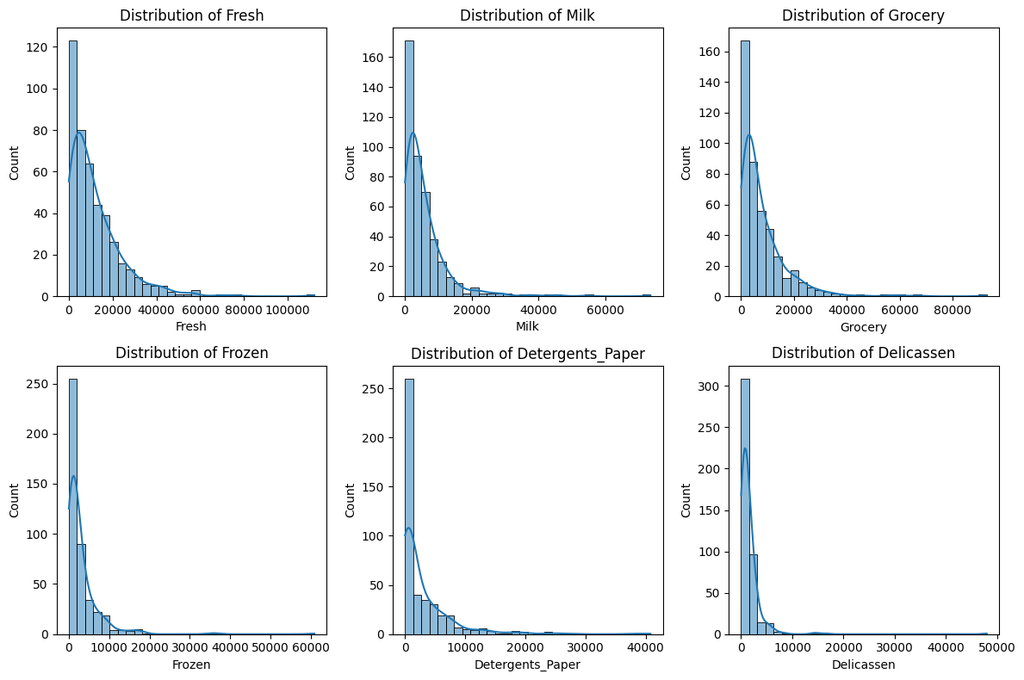

```python
# creating a list with our features

features = ['Fresh', 'Milk', 'Grocery', 'Frozen', 'Detergents_Paper', 'Delicassen']

# Plotting histograms
# Visualizing the distribution of each spending feature

plt.figure(figsize=(12, 8))
for i, col in enumerate(features):
    plt.subplot(2, 3, i+1)
    sns.histplot(df[col], kde=True, bins=30)
    plt.title(f'Distribution of {col}')
plt.tight_layout()
plt.show()
```

We can see that most of the features are skewed to the right! This tells us that clustering might group based on extreme values unless we apply scaling.

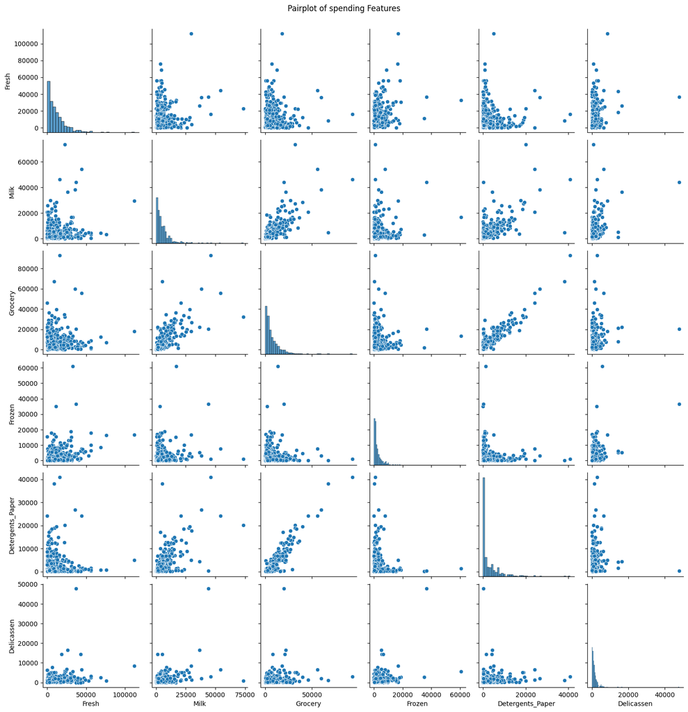

```python
# Plotting a pairplot
# exploring pairwise relationships between spending categories

sns.pairplot(df[features])
plt.suptitle("Pairplot of spending Features", y=1.02)
plt.show()
```

There is a strong positive correlation between Milk, Grocery, and Detergents_Paper. This might mean that those features form natural clusters together. We could also detect redundant features or outliers by visualizing using pairplots.

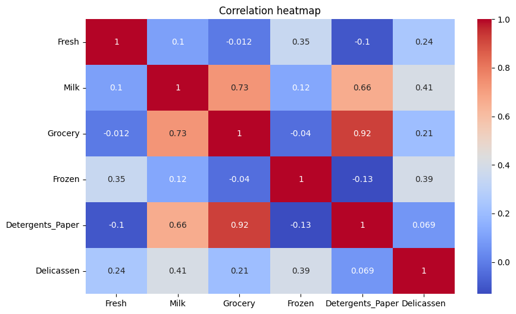

```python
# Correlation heatmap
# to see how strongly correlated features are to each other

plt.figure(figsize=(10, 6))
corr = df[features].corr()
sns.heatmap(corr, annot=True, cmap='coolwarm')
plt.title("Correlation heatmap")
plt.show()
```

We could see that Detergents_Paper is highly correlated with Grocery and Milk, which means that they may form a single cluster or dominate cluster formation unless we do something about it!

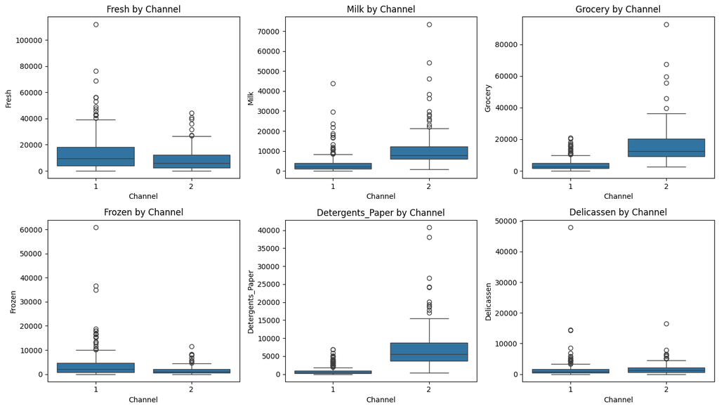

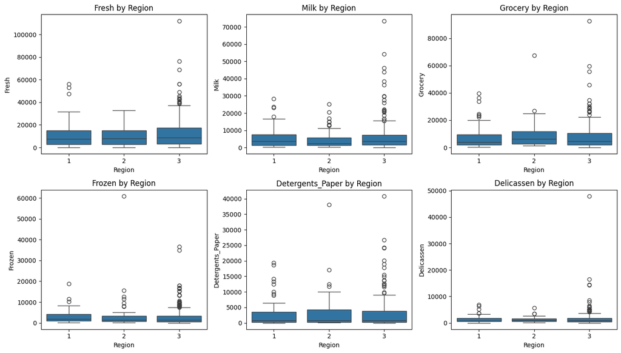

```python
# Boxplots for both, Channel and Region
# to examine how spending patterns change across Channel and Region

# Boxplots by Channel
plt.figure(figsize=(14, 8))
for i, col in enumerate(features):
    plt.subplot(2, 3, i+1)
    sns.boxplot(x='Channel', y=col, data=df)
    plt.title(f'{col} by Channel')
plt.tight_layout()
plt.show()

# Boxplots by Region
plt.figure(figsize=(14, 8))
for i, col in enumerate(features):
    plt.subplot(2, 3, i+1)
    sns.boxplot(x='Region', y=col, data=df)
    plt.title(f'{col} by Region')
plt.tight_layout()
plt.show()
```

We could observe that Horeca clients spend more on Fresh and Frozen products, while Retail clients spend more on Detergents and Grocery. Those differences may align with the clusters!

### Preprocessing

Before we create the clustering model, we have to dive into preprocessing! we have to especially because clustering is highly sensitive to how the data is scaled and shaped.

```python
# Dropping categorical features
# Since we are focused on spending behavior, we will drop Channel and Region for clustering

X = df.drop(['Channel', 'Region'], axis=1)
```

We are clustering based on numerical spending patterns alone, so we don't really need the categorical features even if they are encoded.

```python
# Log transformations
# the data is heavily skewed, meaning a few customers spend a lot more than others
# This compresses the scale and reduces the effect of extreme outliers, making the clusters more balanced

X_log = np.log1p(X)
```

```python
# Scaling the features (Standardization)

scaler = StandardScaler()
X_scaled = scaler.fit_transform(X_log)
```

Features with larger scales would dominate the clusters. Scaling them will ensure all features contribute equally to distance computations!

### Clustering

##### K-Means

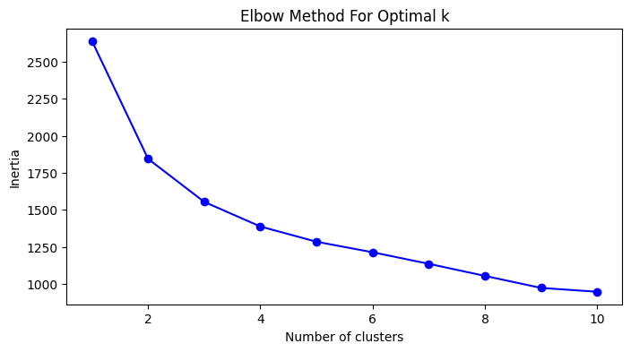

```python
# We will try different values for k to find the optimal number

inertia = []
K =range(1, 11)
for k in K:
    kmeans = KMeans(n_clusters=k, random_state=42)
    kmeans.fit(X_scaled)
    inertia.append(kmeans.inertia_)

# Plotting the elbow method
plt.figure(figsize=(8, 4))
plt.plot(K, inertia, 'bo-')
plt.xlabel('Number of clusters')
plt.ylabel('Inertia')
plt.title('Elbow Method For Optimal k')
plt.show()
```

The elbow appears at k = 3, which is the point in the curve where the inertia starts to flatten out.

```python
# Fitting the model
kmeans = KMeans(n_clusters=3, random_state=42)
kmeans.fit(X_scaled)
labels_kmeans = kmeans.labels_
```

Why K-Means? I used K-Means because it is simple and fast to use, and it works well when clusters are spherical and balanced. It helps reveal natural customer groups based on similar spending habits, and it also works well after scaling.

Pros?

- It is easy to implement and interpret
- Scalable to large datasets
- Efficient when it comes to time complexity

Cons?

- It is sensitive to outliers and initial centroid placement
- It is required to predefine the number of clusters (k)
- It doesn't handle nonspherical clusters well

##### Agglomerative Clustering

```python
# Fitting the model

agg = AgglomerativeClustering(n_clusters=3)
labels_agg = agg.fit_predict(X_scaled)
```

Why use Agglomerative Clustering? It doesn't require k to be defined upfront when visualized with a dendrogram. It captures more organic and less symmetrical cluster shapes. Finally, it is good for smaller datasets like this one.

Pros?

- It doesn't assume the shape or size of the clusters
- We can choose k by visualizing with a dendrogram
- It is more robust to noise and outliers in some cases

Cons?

- It is not scalable to very large datasets and is very computationally expensive
- a cluster cannot be split once it is merged

### Clustering Analysis

We arrived at 3 clusters after using K-Means and Agglomerative, Let us analyze our clusters now!

```python
df_clustered = df.copy()
df_clustered['Cluster'] = labels_kmeans

# Grouping by clusters and getting mean values
cluster_summary = df_clustered.groupby('Cluster').mean()
print(cluster_summary)
```

```
          Channel    Region         Fresh          Milk       Grocery  \
Cluster
0        1.580247  2.530864   2809.444444   6945.901235  12232.567901
1        1.013889  2.500000  12399.537037   2087.828704   2554.074074
2        1.643357  2.615385  16603.258741  10746.629371  13678.629371

              Frozen  Detergents_Paper   Delicassen
Cluster
0         588.123457       5382.851852   782.345679
1        3286.509259        427.435185   919.439815
2        4154.727273       5171.468531  2859.958042
```

Cluster 0: High spending on Grocery, Milk, and Detergents_paper. Low spending on Fresh, Frozen, and Delicassen. The customers seem to prioritize shelf stable or processed goods, which align with retail shops, convenience stores, or small stores, where the volume of product or shelf life matter more than freshness.

Cluster 1: High spending on Fresh, moderate spending on Frozen, and Low spending on everything else. This cluster is focused on fresh goods and some frozen foods, which is typical of restaurants, hotels, or catering services, where freshness is key and there is less emphasis in grocery or paper products.

Cluster 2: High spending on Fresh, Milk, and Grocery, and decent spending on everything else. Those are likely high volume buyers like large hotels or wholesale food services. They buy everything in bulk indicating larger scale operations with different needs.

We could tailor marketing strategies and make inventory decisions based on these clusters! Understanding these segments could help businesses optimize product offerings and even predict future buying behavior.

### Impact of this project

##### Positive Impacts

1. Improving business efficiency: businesses can tailor marketing strategies, manage inventory more effectively, and streamline supply chains, reducing waste and improving profit margins.
2. Personalizing th customer experience: Clustering allows suppliers to understand different customer needs and behaviors.
3. Data driven decision making: Companies can rely on empirical evidence to inform their operations instead of assumptions

##### Negative Impacts

1. Missing the data and privacy issues: Improper use of clustering insights might lead to intrusive profiling or discrimination.
2. Bias: outliers or niche customers might be ignored.
3. Questionable ethical decisions: There is a risk that high value customers like cluster 2 are prioritized unfairly. This can reinforce inequality!

### References

- ChatGPT : I used ChatGPT to help me understand some aspects of this project, such as getting help with understanding the clustering models
- Keggle.com : I used the Wholesale customers dataset from keggle
- Canvas : I used available resources from modules in Canvas